# Design matrices for models

22 April 2026

## Goals for today

- Understand how to create design matrices for use in linear models
- Recognize the different coding schemes for factor models
- See how to use `model.matrix()` for creating & extracting design matrices

## Models in matrix form

Recall the matrix form for our linear models, where

\[ \mathbf{y} = \mathbf{X} \boldsymbol{\beta} + \mathbf{e} \\ \mathbf{e} \sim \text{MVN}(\mathbf{0}, \boldsymbol{\Sigma}) \]

## Models in matrix form

Let’s write out this model in more detail

\[ \mathbf{y} = \mathbf{X} \boldsymbol{\beta} + \mathbf{e} \\ \Downarrow \\ \begin{bmatrix} y_1 \\ y_2 \\ \vdots \\ y_n \end{bmatrix} = \begin{bmatrix} 1 & x_{1,1} & \cdots & x_{n,1} \\ 1 & x_{1,2} & \cdots & x_{n,2} \\ \vdots & \vdots & \ddots & \vdots \\ 1 & x_{1,n} & \cdots & x_{n,n} \end{bmatrix} \begin{bmatrix} \beta_0 \\ \beta_1 \\ \vdots \\ \beta_n \end{bmatrix} + \begin{bmatrix} e_1 \\ e_2 \\ \vdots \\ e_n \end{bmatrix} \]

## Models in matrix form

Let’s write out this model in more detail

\[ \mathbf{y} = \mathbf{X} \boldsymbol{\beta} + \mathbf{e} \\ \Downarrow \\ \begin{bmatrix} y_1 \\ y_2 \\ \vdots \\ y_n \end{bmatrix} = \begin{bmatrix} 1 & x_{1,1} & \cdots & x_{n,1} \\ 1 & x_{1,2} & \cdots & x_{n,2} \\ \vdots & \vdots & \ddots & \vdots \\ 1 & x_{1,n} & \cdots & x_{n,n} \end{bmatrix} \begin{bmatrix} \beta_0 \\ \beta_1 \\ \vdots \\ \beta_n \end{bmatrix} + \begin{bmatrix} e_1 \\ e_2 \\ \vdots \\ e_n \end{bmatrix} \]

We say the columns in \(\mathbf{X}\) define the *design* of the analysis

## Ordinary least squares

Also recall that we can use \(\mathbf{X}\) to solve for \(\hat{\mathbf{y}}\)

\[ \begin{align} \hat{\mathbf{y}} &= \mathbf{X} \hat{\boldsymbol{\beta}} \\ &= \mathbf{X} \left( (\mathbf{X}^{\top} \mathbf{X})^{-1} \mathbf{X}^{\top} \mathbf{y} \right) \\ &= \underbrace{\mathbf{X} (\mathbf{X}^{\top} \mathbf{X})^{-1} \mathbf{X}^{\top}}_{\mathbf{H}} \mathbf{y} \\ &= \mathbf{H} \mathbf{y} \end{align} \]

Understanding the form of \(\mathbf{X}\) is critical to our inference

## A simple starting point

### Data = (Deterministic part) + (Stochastic part)

## Types of linear models

We classify linear models by the form of their deterministic part

Discrete predictor \(\rightarrow\) ANalysis Of VAriance (ANOVA)

Continuous predictor \(\rightarrow\) Regression

Both \(\rightarrow\) ANalysis of COVAriance (ANCOVA)

## Possible models for growth of fish

| Model | Description |
| --- | --- |
| \(\text{growth}_i = \beta_0 + \beta_{1,\text{species}} + \epsilon_i\) | 1-way ANOVA |
| \(\text{growth}_i = \beta_0 + \beta_{1,\text{species}} + \beta_{2,\text{tank}} + \epsilon_i\) | 2-way ANOVA |
| \(\text{growth}_i = \beta_0 + \beta_1 \text{ration}_i + \epsilon_i\) | simple linear regression |
| \(\text{growth}_i = \beta_0 + \beta_1 \text{ration}_i + \beta_2 \text{temperature}_i + \epsilon_i ~ ~\) | multiple regression |
| \(\text{growth}_i = \beta_0 + \beta_{1,\text{species}} + \beta_2 \text{ration}_i + \epsilon_i\) | ANCOVA |

## Defining models with \(\mathbf{X}\)

### Mean only

How would we write \(\mathbf{X}\) for a simple model that included a mean only?

\[ \mathbf{y} = \boldsymbol{\mu} + \mathbf{e} \]

## Defining models with \(\mathbf{X}\)

### Mean only

Let’s start by rewriting our model

\[ \mathbf{y} = \boldsymbol{\mu} + \mathbf{e} \\ \Downarrow \\ \mathbf{y} = \boldsymbol{\beta}_0 + \mathbf{e} \\ \Downarrow \\ \mathbf{y} = \begin{bmatrix} \beta_0 \\ \beta_0 \\ \vdots \\ \beta_0 \end{bmatrix} + \mathbf{e} \]

## Defining models with \(\mathbf{X}\)

### Mean only

and factor out the \(\beta\)’s

\[ \mathbf{y} = \begin{bmatrix} \beta_0 \\ \beta_0 \\ \vdots \\ \beta_0 \end{bmatrix} + \mathbf{e} ~~~ \Rightarrow ~~~ \mathbf{y} = \begin{bmatrix} 1 \\ 1 \\ \vdots \\ 1 \end{bmatrix} \beta_0 + \mathbf{e} \]

## Defining models with \(\mathbf{X}\)

### Mean only

and then redefine \(\mathbf{X}\) and \(\boldsymbol{\beta}\)

\[ \mathbf{y} = \begin{bmatrix} 1 \\ 1 \\ \vdots \\ 1 \end{bmatrix} \beta_0 + \mathbf{e} ~~~ \Rightarrow ~~~ \mathbf{y} = \mathbf{X} \boldsymbol{\beta} + \mathbf{e} \]

with \(\mathbf{X} = [1 ~ 1 \cdots 1]^{\top}\) and \(\boldsymbol{\beta} = [\beta_0]\)

## Defining models with \(\mathbf{X}\)

### Regression

What would \(\mathbf{X}\) look like for a regression model with 2 predictors?

\[ y_i = \beta_0 + \beta_1 x_{1,i} + \beta_2 x_{2,i} + e_i \\ \Downarrow ? \\ \mathbf{y} = \mathbf{X} \boldsymbol{\beta} + \mathbf{e} \]

## Defining models with \(\mathbf{X}\)

### Regression

\[ \mathbf{y} = \mathbf{X} \boldsymbol{\beta} + \mathbf{e} \\ \Downarrow \\ \begin{bmatrix} y_1 \\ y_2 \\ \vdots \\ y_n \end{bmatrix} = \begin{bmatrix} 1 & x_{1,1} & x_{2,1} \\ 1 & x_{1,2} & x_{2,2} \\ \vdots & \vdots & \vdots \\ 1 & x_{1,n} & x_{2,n} \end{bmatrix} \begin{bmatrix} \beta_0 \\ \beta_1 \\ \beta_2 \end{bmatrix} + \begin{bmatrix} e_1 \\ e_2 \\ \vdots \\ e_n \end{bmatrix} \]

## Defining models with \(\mathbf{X}\)

### Regression

What about a model with an intercept and linear increase over time \(t\)?

\[ y_t = \beta_0 + \beta_1 t + e_t \\ \Downarrow ? \\ \mathbf{y} = \mathbf{X} \boldsymbol{\beta} + \mathbf{e} \]

## Defining models with \(\mathbf{X}\)

### Regression

\[ \mathbf{y} = \mathbf{X} \boldsymbol{\beta} + \mathbf{e} \\ \Downarrow \\ \begin{bmatrix} y_1 \\ y_2 \\ \vdots \\ y_n \end{bmatrix} = \begin{bmatrix} 1 & ? \\ 1 & ? \\ \vdots & \vdots \\ 1 & ? \end{bmatrix} \begin{bmatrix} \beta_0 \\ \beta_1 \end{bmatrix} + \begin{bmatrix} e_1 \\ e_2 \\ \vdots \\ e_n \end{bmatrix} \]

## Defining models with \(\mathbf{X}\)

### Regression

\[ \mathbf{y} = \mathbf{X} \boldsymbol{\beta} + \mathbf{e} \\ \Downarrow \\ \begin{bmatrix} y_1 \\ y_2 \\ y_3 \\ \vdots \\ y_n \end{bmatrix} = \begin{bmatrix} 1 & 1 \\ 1 & 2 \\ 1 & 3 \\ \vdots & \vdots \\ 1 & n \end{bmatrix} \begin{bmatrix} \beta_0 \\ \beta_1 \end{bmatrix} + \begin{bmatrix} e_1 \\ e_2 \\ e_3 \\ \vdots \\ e_n \end{bmatrix} \]

## Defining models with \(\mathbf{X}\)

### Analysis of variance (ANOVA)

ANOVA was popularized by [Ronald Fisher](https://en.wikipedia.org/wiki/Ronald_Fisher) ~100 years ago when he was studying the variance of genetic traits among commercial crops

ANOVA is used to analyze *differences among group means*

## Comparing group means

Recall our analysis of fish growth as a function of ration

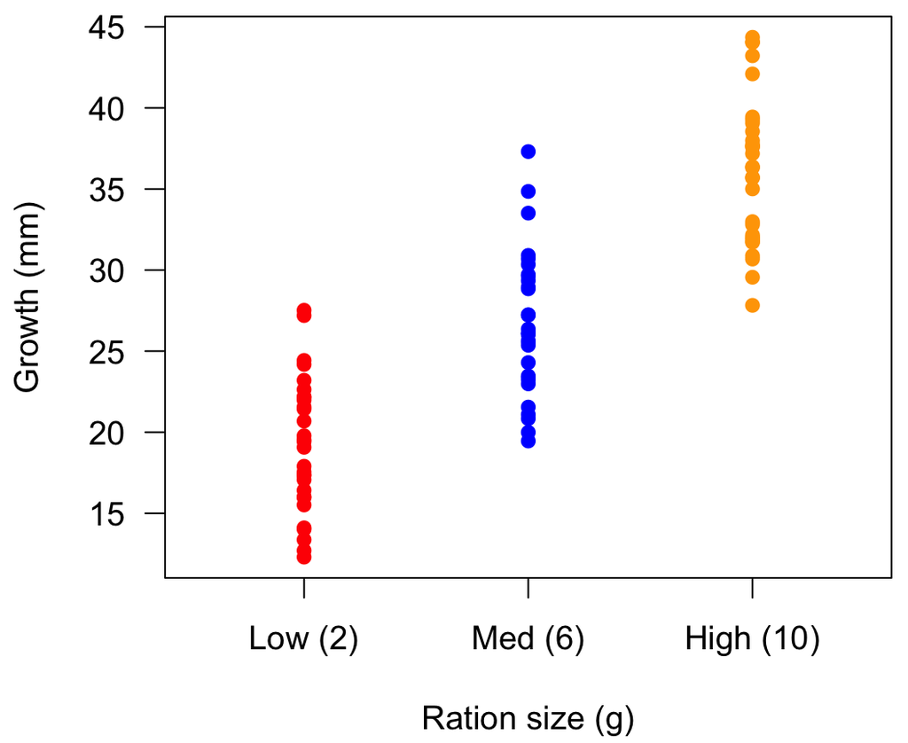

## Defining models with \(\mathbf{X}\)

### ANOVA

Here we want to know if the mean growth of fish varies among the 3 ration sizes

\[ \bar{g}_{\text{ration}_1} \overset{?}{=} \bar{g}_{\text{ration}_2} \overset{?}{=} \bar{g}_{\text{ration}_3} \]

How would we write the model for this?

## Defining models with \(\mathbf{X}\)

### ANOVA

Our model for an observation \(y_i\) is something like

\[ y_i = \mu_i + e_i \\ ~ \\ \mu_i = \begin{cases} \mu_1 & \text{if fed ration 1} \\ \mu_2 & \text{if fed ration 2} \\ \mu_3 & \text{if fed ration 3} \end{cases} \]

## Defining models with \(\mathbf{X}\)

### ANOVA

We can use binary 0/1 coding to represent if/then constructs

\[ y_i = \mu_1 x_{1,i} + \mu_2 x_{2,i} + \mu_3 x_{3,i} + e_i \\ ~ \\ x_{1,i} = 1 ~ \text{if fed ration 1 and 0 otherwise} \\ x_{2,i} = 1 ~ \text{if fed ration 2 and 0 otherwise} \\ x_{3,i} = 1 ~ \text{if fed ration 3 and 0 otherwise} \]

## Defining models with \(\mathbf{X}\)

### ANOVA

How would we specify the model matrix \(\mathbf{X}\) for this?

## Defining models with \(\mathbf{X}\)

### ANOVA

Let’s rewrite our model as

\[ y_i = \beta_1 x_{1,i} + \beta_2 x_{2,i} + \beta_3 x_{3,i} + e_i \\ \Downarrow \\ \mathbf{y} = \mathbf{X} \boldsymbol{\beta} + \mathbf{e} \]

## Defining models with \(\mathbf{X}\)

### ANOVA

And define \(\mathbf{X}\) as

\[ \mathbf{X} = \begin{bmatrix} x_{1,1} & x_{2,1} & x_{3,1} \\ x_{1,2} & x_{2,2} & x_{3,2} \\ \vdots & \vdots & \vdots \\ x_{1,n} & x_{2,n} & x_{3,n} \end{bmatrix} \]

## Defining models with \(\mathbf{X}\)

Let’s now re-order all of the observations into their 3 ration groups

\[ \mathbf{y} = \begin{bmatrix} y_{1,1} \\ \vdots \\ y_{1,j_1} \\ \hline y_{2,1} \\ \vdots \\ y_{2,j_2} \\ \hline y_{3,1} \\ \vdots \\ y_{3,j_3} \end{bmatrix} ~ \text{with} ~ j_1 + j_2 + j_3 = n \]

## Defining models with \(\mathbf{X}\)

We can then define \(\mathbf{X}\) and \(\boldsymbol{\beta}\) as

\[ \mathbf{X} = \begin{bmatrix} 1 & 0 & 0 \\ \vdots & \vdots & \vdots \\ 1 & 0 & 0 \\ \hline 0 & 1 & 0 \\ \vdots & \vdots & \vdots \\ 0 & 1 & 0 \\ \hline 0 & 0 & 1 \\ \vdots & \vdots & \vdots \\ 0 & 0 & 1 \end{bmatrix} ~~~ \boldsymbol{\beta} = \begin{bmatrix} \beta_1 \\ \beta_2 \\ \beta_3 \end{bmatrix} \]

## Defining models with \(\mathbf{X}\)

### ANOVA

Here are the mean growth rates of our 3 groups of fish

\(\bar{y}_{j=1} = \beta_1 =\) 19.2

\(\bar{y}_{j=2} = \beta_2 =\) 26.7

\(\bar{y}_{j=3} = \beta_3 =\) 36.2

## Defining models with \(\mathbf{X}\)

### ANOVA

And here are the results of our ANOVA model

```r
## fit ANOVA w/ `- 1` to remove intercept
m1 <- lm(yy ~ ration - 1)
coef(m1) |> round(1)
```

```
## ration_1 ration_2 ration_3
##     19.2     26.7     36.2
```

This confirms that we have fit a model of means

## Defining models with \(\mathbf{X}\)

### ANOVA

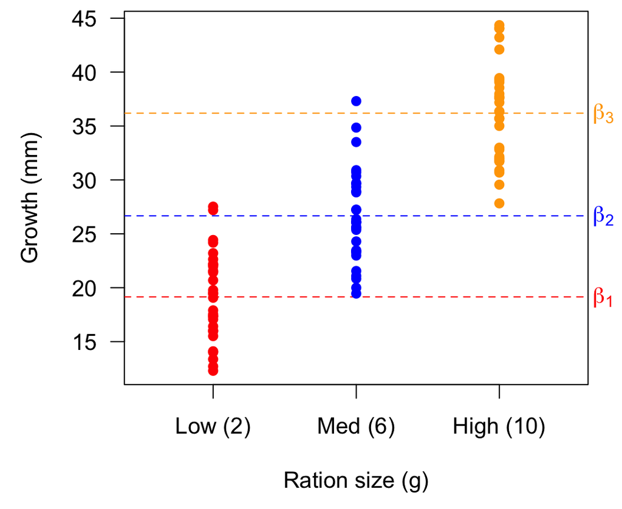

## Defining models with \(\mathbf{X}\)

### ANOVA

Suppose we wanted to reframe our model to instead include the effect of ration relative to the overall mean growth rate \((\mu)\)

\[ y_i = \mu + \beta_1 x_{1,i} + \beta_2 x_{2,i} + \beta_3 x_{3,i} + e_i \] and calculate the groups means as

\[ \bar{y}_{j=1} = \mu + \beta_1 \\ \bar{y}_{j=2} = \mu + \beta_2 \\ \bar{y}_{j=3} = \mu + \beta_3 \]

## Defining models with \(\mathbf{X}\)

We would then define \(\mathbf{X}\) and \(\boldsymbol{\beta}\) as

\[ \mathbf{X} = \begin{bmatrix} 1 & 1 & 0 & 0 \\ \vdots & \vdots & \vdots & \vdots \\ 1 & 1 & 0 & 0 \\ \hline 1 & 0 & 1 & 0 \\ \vdots & \vdots & \vdots & \vdots \\ 1 & 0 & 1 & 0 \\ \hline 1 & 0 & 0 & 1 \\ \vdots & \vdots & \vdots & \vdots \\ 1 & 0 & 0 & 1 \end{bmatrix} ~~~ \boldsymbol{\beta} = \begin{bmatrix} \mu \\ \beta_1 \\ \beta_2 \\ \beta_3 \end{bmatrix} \]

## Defining models with \(\mathbf{X}\)

### ANOVA

And here are the results of our ANOVA model

```r
## design matrix
X <- cbind(rep(1,nn*pp), ration)
## fit ANOVA w/ `- 1` to remove intercept
m2 <- lm(yy ~ X - 1)
coef(m2) |> round(1)
```

```
##     X   X_1   X_2   X_3
##  36.2 -17.0  -9.5    NA
```

**Wait – what happened here?!**

## Defining models with \(\mathbf{X}\)

Can you spot the problem in our design matrix?

\[ \mathbf{X} = \begin{bmatrix} 1 & 1 & 0 & 0 \\ \vdots & \vdots & \vdots & \vdots \\ 1 & 1 & 0 & 0 \\ \hline 1 & 0 & 1 & 0 \\ \vdots & \vdots & \vdots & \vdots \\ 1 & 0 & 1 & 0 \\ \hline 1 & 0 & 0 & 1 \\ \vdots & \vdots & \vdots & \vdots \\ 1 & 0 & 0 & 1 \end{bmatrix} \]

## Defining models with \(\mathbf{X}\)

### ANOVA

Let’s estimate the \(\beta_i\)’s by hand

```r
## solve for beta by hand
beta <- solve(t(X) %*% X) %*% t(X) %*% yy
```

```
## Error in solve.default(t(X) %*% X) :
##   system is computationally singular: reciprocal condition number
```

**This is not going well…**

## Defining models with \(\mathbf{X}\)

\(\mathbf{X}\) is *rank-deficient* because \(\mathbf{X}_{(\cdot 1)} = \mathbf{X}_{(\cdot 2)} + \mathbf{X}_{(\cdot 3)} + \mathbf{X}_{(\cdot 4)}\)

\[ \mathbf{X} = \begin{bmatrix} 1 & 1 & 0 & 0 \\ \vdots & \vdots & \vdots & \vdots \\ 1 & 1 & 0 & 0 \\ \hline 1 & 0 & 1 & 0 \\ \vdots & \vdots & \vdots & \vdots \\ 1 & 0 & 1 & 0 \\ \hline 1 & 0 & 0 & 1 \\ \vdots & \vdots & \vdots & \vdots \\ 1 & 0 & 0 & 1 \end{bmatrix} \]

## Defining models with \(\mathbf{X}\)

### ANOVA

Let’s think about our model again

\[ y_i = \mu + \beta_1 x_{1,i} + \beta_2 x_{2,i} + \beta_3 x_{3,i} + e_i \] where we want the group means to be

\[ \bar{y}_{j=1} = \mu + \beta_1 \\ \bar{y}_{j=2} = \mu + \beta_2 \\ \bar{y}_{j=3} = \mu + \beta_3 \]

## Defining models with \(\mathbf{X}\)

### ANOVA

Consider the overall mean of \(\mathbf{y}\) in terms of the group means

\[ \bar{y} = \frac{\bar{y}_{j=1} + \bar{y}_{j=2} + \bar{y}_{j=3}}{3} \\ \]

## Defining models with \(\mathbf{X}\)

### ANOVA

Consider the overall mean of \(\mathbf{y}\) in terms of the group means

\[ \bar{y} = \frac{\bar{y}_{j=1} + \bar{y}_{j=2} + \bar{y}_{j=3}}{3} \\ \Downarrow \\ \mu = \frac{(\mu + \beta_1) + (\mu + \beta_2) + (\mu + \beta_3)}{3} \\ \Downarrow \\ \mu = \frac{3 \mu + (\beta_1 + \beta_2 + \beta_3)}{3} \\ \Downarrow \\ (\beta_1 + \beta_2 + \beta_3) = 0 \]

## Defining models with \(\mathbf{X}\)

### ANOVA

If we substitute for \(\beta_3\)

\[ (\beta_1 + \beta_2 + \beta_3) = 0 ~ \Rightarrow ~ \beta_3 = \text{-} \beta_1 + \text{-} \beta_2 \]

we can rewrite our model as

\[ y_i = \mu + \beta_1 x_{1,i} + \beta_2 x_{2,i} + (\text{-} \beta_1 + \text{-} \beta_2) x_{3,i} + e_i \] and calculate the group means as

\[ \begin{aligned} \bar{y}_{j=1} &= \mu + \beta_1 \\ \bar{y}_{j=2} &= \mu + \beta_2 \\ \bar{y}_{j=3} &= \mu - (\beta_1 + \beta_2) \end{aligned} \]

## Defining models with \(\mathbf{X}\)

We would then define \(\mathbf{X}\) and \(\boldsymbol{\beta}\) as

\[ \mathbf{X} = \begin{bmatrix} 1 & 1 & 0 \\ \vdots & \vdots & \vdots \\ 1 & 1 & 0 \\ \hline 1 & 0 & 1 \\ \vdots & \vdots & \vdots \\ 1 & 0 & 1 \\ \hline 1 & -1 & -1 \\ \vdots & \vdots & \vdots \\ 1 & -1 & -1 \end{bmatrix} ~~~ \boldsymbol{\beta} = \begin{bmatrix} \mu \\ \beta_1 \\ \beta_2 \end{bmatrix} \]

## Defining models with \(\mathbf{X}\)

### ANOVA

```r
## empty design matrix
XX <- matrix(NA, nn*pp, pp)
## for mu
XX[i1,] <- matrix(c(1,  1,  0), nn, pp, byrow = TRUE)
## for beta_1
XX[i2,] <- matrix(c(1,  0,  1), nn, pp, byrow = TRUE)
## for beta_2
XX[i3,] <- matrix(c(1, -1, -1), nn, pp, byrow = TRUE)
## fit model & get parameters
Bvec <- coef(lm(yy ~ XX - 1))
names(Bvec) <- c("mu", "beta_1", "beta_2")
Bvec
```

```
##         mu     beta_1     beta_2
## 27.3360624 -8.1828690 -0.6680819
```

## Defining models with \(\mathbf{X}\)

### ANOVA

```r
## mean of ration 1
Bvec["mu"] + Bvec["beta_1"]
## mean of ration 2
Bvec["mu"] + Bvec["beta_2"]
## mean of ration 3
Bvec["mu"] - (Bvec["beta_1"] + Bvec["beta_2"])
```

```
##       mu
## 19.15319
##       mu
## 26.66798
##       mu
## 36.18701
```

## Defining models with \(\mathbf{X}\)

### ANOVA

We could also fit our grand mean model after some simple algebra

\[ y_i = \mu + \beta_1 x_{1,i} + \beta_2 x_{2,i} + \beta_3 x_{3,i} + e_i \\ \Downarrow \\ y_i - \mu = \beta_1 x_{1,i} + \beta_2 x_{2,i} + \beta_3 x_{3,i} + e_i \\ \Downarrow \\ y_i - \bar{y} = \beta_1 x_{1,i} + \beta_2 x_{2,i} + \beta_3 x_{3,i} + e_i \]

## Defining models with \(\mathbf{X}\)

### ANOVA

```r
## fit anova with implicit grand mean
m2 <- lm((yy - mean(yy)) ~ ration - 1)
coef(m2)
```

```
##   ration_1   ration_2   ration_3
## -8.1828690 -0.6680819  8.8509509
```

## Defining models with \(\mathbf{X}\)

### ANOVA

```r
## do we recover our means?
coef(m2) + mean(yy)
```

```
## ration_1 ration_2 ration_3
## 19.15319 26.66798 36.18701
```

```r
coef(m1)
```

```
## ration_1 ration_2 ration_3
## 19.15319 26.66798 36.18701
```

## Comparing group means

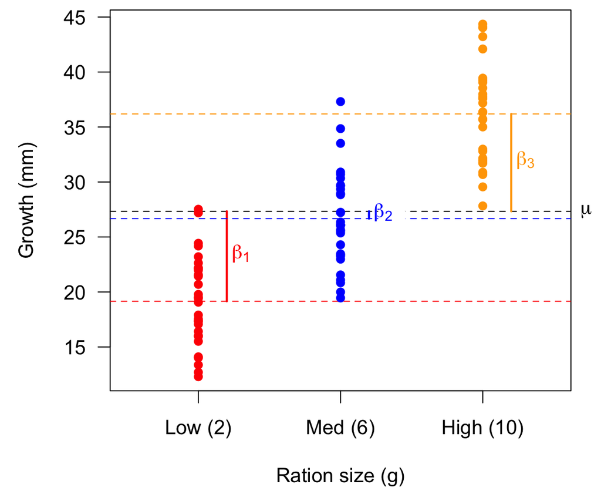

## Defining models with \(\mathbf{X}\)

### ANOVA

What if we wanted to treat one group as a control or reference (eg, our low ration) and estimate the other effects relative to it?

\[ y_i = \beta_1 x_{1,i} + (\beta_1 + \beta_2) x_{2,i} + (\beta_1 + \beta_3) x_{3,i} + e_i \]

such that

\[ \begin{align} \bar{y}_{j=1} &= \beta_1 \\ \bar{y}_{j=2} &= \beta_1 + \beta_2 \\ \bar{y}_{j=3} &= \beta_1 + \beta_3 \end{align} \]

## Defining models with \(\mathbf{X}\)

We would define \(\mathbf{X}\) and \(\boldsymbol{\beta}\) as

\[ \mathbf{X} = \begin{bmatrix} 1 & 0 & 0 \\ \vdots & \vdots & \vdots \\ 1 & 0 & 0 \\ \hline 1 & 1 & 0 \\ \vdots & \vdots & \vdots \\ 1 & 1 & 0 \\ \hline 1 & 0 & 1 \\ \vdots & \vdots & \vdots \\ 1 & 0 & 1 \end{bmatrix} ~~~ \boldsymbol{\beta} = \begin{bmatrix} \beta_1 \\ \beta_2 \\ \beta_3 \end{bmatrix} \]

## Defining models with \(\mathbf{X}\)

### ANOVA

```r
## empty design matrix
XX <- matrix(NA, nn*pp, pp)
## for beta_1
XX[i1,] <- matrix(c(1, 0, 0), nn, pp, byrow = TRUE)
## for beta_1 + beta_2
XX[i2,] <- matrix(c(1, 1, 0), nn, pp, byrow = TRUE)
## for beta_1 + beta_3
XX[i3,] <- matrix(c(1, 0, 1), nn, pp, byrow = TRUE)
## fit anova with implicit grand mean
Bvec <- coef(lm(yy ~ XX - 1))
names(Bvec) <- c("beta_1", "beta_2", "beta_3")
Bvec
```

```
##    beta_1    beta_2    beta_3
## 19.153193  7.514787 17.033820
```

## Defining models with \(\mathbf{X}\)

### ANOVA

```r
## mean of ration 1
Bvec["beta_1"]
## mean of ration 2
Bvec["beta_1"] + Bvec["beta_2"]
## mean of ration 3
Bvec["beta_1"] + Bvec["beta_3"]
```

```
##   beta_1
## 19.15319
##   beta_1
## 26.66798
##   beta_1
## 36.18701
```

## Comparing group means

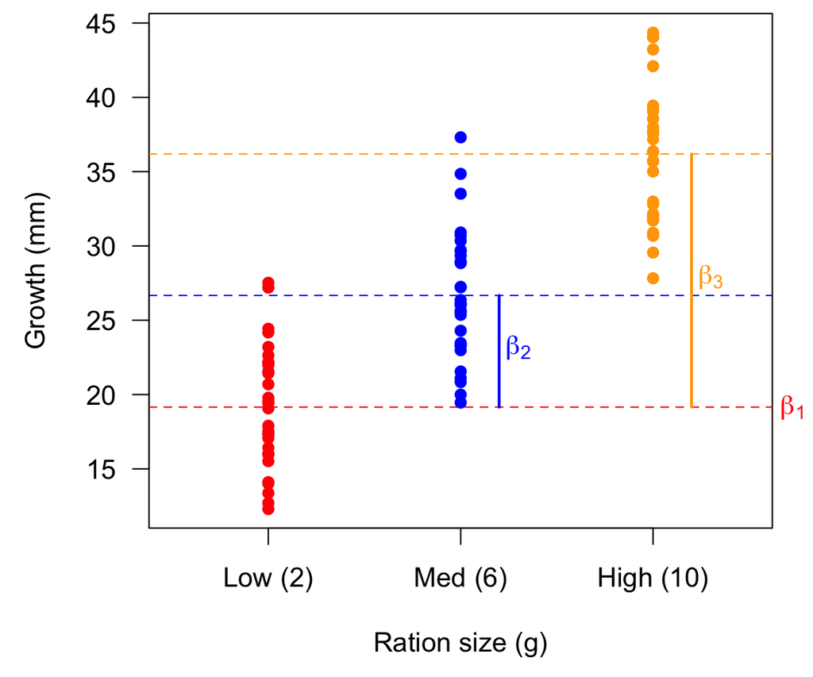

## Analysis of covariance (ANCOVA)

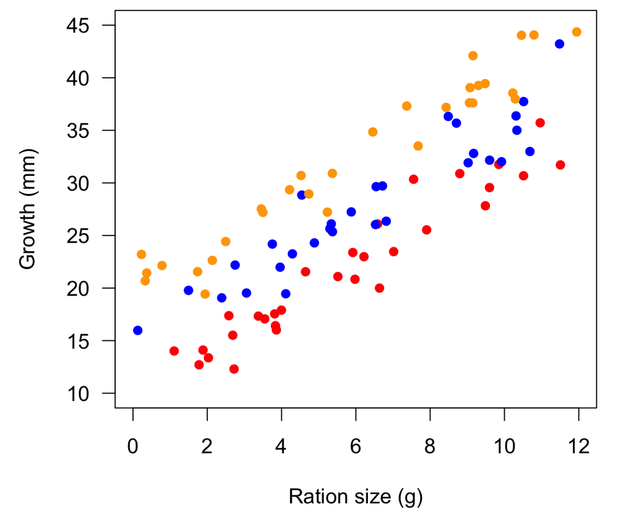

## Analysis of covariance (ANCOVA)

Here is our model with the categorical effect of lineage & the continuous effect of ration

\[ \text{growth}_i = \alpha + \beta_{1,\text{lineage}} + \beta_2 \text{ration}_i + \epsilon_i \]

## Analysis of covariance (ANCOVA)

Dropping the global intercept & writing out the lineage effects yields

\[ \text{growth}_i = \underbrace{\beta_1 x_{1,i} + \beta_2 x_{2,i} + \beta_3 x_{3,i}}_{\text{lineage}} + \underbrace{\beta_4 x_{4,i}}_{\text{ration}} + e_i \]

## Defining models with \(\mathbf{X}\)

We would then define \(\mathbf{X}\) and \(\boldsymbol{\beta}\) as

\[ \mathbf{X} = \begin{bmatrix} 1 & 0 & 0 & r_1 \\ \vdots & \vdots & \vdots & \vdots \\ 1 & 0 & 0 & r_{j_1} \\ \hline 0 & 1 & 0 & r_{j_1+1} \\ \vdots & \vdots & \vdots & \vdots \\ 0 & 1 & 0 & r_{j_2+j_2} \\ \hline 0 & 0 & 1 & r_{j_1+j_2+1} \\ \vdots & \vdots & \vdots & \vdots \\ 0 & 0 & 1 & r_n \end{bmatrix} ~~~ \boldsymbol{\beta} = \begin{bmatrix} \beta_1 \\ \beta_2 \\ \beta_3 \\ \beta_4 \end{bmatrix} \]

## Analysis of covariance (ANCOVA)

```r
## create design matrix
XX <- cbind(L1 = rep(c(1,0,0), ea = nn), # col 1: effect of lineage 1
            L2 = rep(c(0,1,0), ea = nn), # col 2: effect of lineage 2
            L3 = rep(c(0,0,1), ea = nn), # col 3: effect of lineage 3
            RA = x_cov)                  # col 4: effect of ration
## fit model
Bvec <- coef(lm(yy ~ XX - 1))
names(Bvec) <- c("beta_1", "beta_2", "beta_3", "beta_4")
Bvec
```

```
##    beta_1    beta_2    beta_3    beta_4
##  9.936056 14.732702 19.688984  2.076631
```

## Analysis of covariance (ANCOVA)

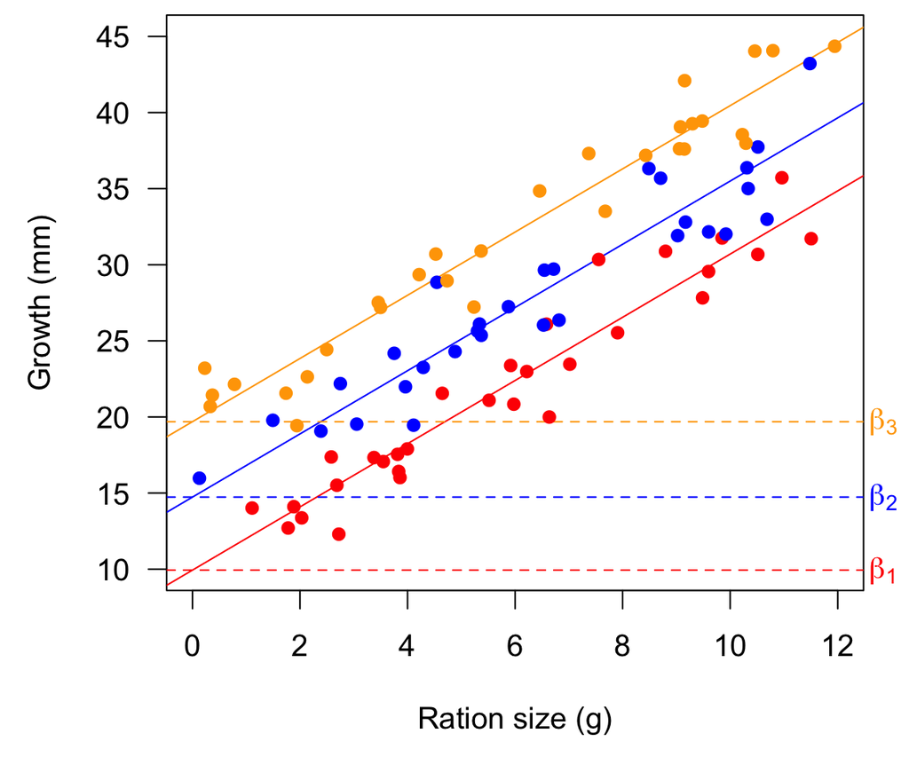

## Design matrices with `model.matrix()`

We have been building our design matrices by hand, but we could instead use

`model.matrix()` with `factor()`

## Design matrices with `model.matrix()`

`factor(x)` tells **R** to treat `x` as categorical

```r
## 2 groups with 2 obs each
groups <- factor(c(1, 1, 2, 2))
## inspect them
groups
```

```
## [1] 1 1 2 2
## Levels: 1 2
```

## Design matrices with `model.matrix()`

`model.matrix(~ x)` uses a right-hand side formula `~ x`

```r
## create design matrix from `groups`
model.matrix(~ groups)
```

```
##   (Intercept) groups2
## 1           1       0
## 2           1       0
## 3           1       1
## 4           1       1
## attr(,"assign")
## [1] 0 1
## attr(,"contrasts")
## attr(,"contrasts")$groups
## [1] "contr.treatment"
```

## Design matrices with `model.matrix()`

What if we don’t use `factor()`?

```r
## 2 groups with 2 obs each
groups <- c(1, 1, 2, 2)
## create design matrix from `groups`
model.matrix(~ groups)
```

```
##   (Intercept) groups
## 1           1      1
## 2           1      1
## 3           1      2
## 4           1      2
## attr(,"assign")
## [1] 0 1
```

## Design matrices with `model.matrix()`

You can drop the intercept term with `- 1`

```r
## 2 groups with 2 obs each
groups <- factor(c(1, 1, 2, 2))
## create design matrix from `groups`
model.matrix(~ groups - 1)
```

```
##   groups1 groups2
## 1       1       0
## 2       1       0
## 3       0       1
## 4       0       1
## attr(,"assign")
## [1] 1 1
## attr(,"contrasts")
## attr(,"contrasts")$groups
## [1] "contr.treatment"
```

## Design matrices with `model.matrix()`

The names/categories are irrelevant for `factor()`

```r
## 2 groups with 2 obs each
groups <- factor(c("ref", "ref", "exp", "exp"))
## create design matrix from `groups`
model.matrix(~ groups)
```

```
##   (Intercept) groupsref
## 1           1         1
## 2           1         1
## 3           1         0
## 4           1         0
## attr(,"assign")
## [1] 0 1
## attr(,"contrasts")
## attr(,"contrasts")$groups
## [1] "contr.treatment"
```

## Design matrices with `model.matrix()`

**R** assigns factors in alphabetical order; the *reference* is first

```r
## 2 groups with 2 obs each
groups <- factor(c("ref", "ref", "exp", "exp"))
## create design matrix from `groups`
model.matrix(~ groups)
```

```
##   (Intercept) groupsref
## 1           1         1
## 2           1         1
## 3           1         0
## 4           1         0
## attr(,"assign")
## [1] 0 1
## attr(,"contrasts")
## attr(,"contrasts")$groups
## [1] "contr.treatment"
```

## Design matrices with `model.matrix()`

We can change the reference case with `relevel()`

```r
## 2 groups with 2 obs each
groups <- relevel(groups, "ref")
## create design matrix from `groups`
model.matrix(~ groups)
```

```
##   (Intercept) groupsexp
## 1           1         0
## 2           1         0
## 3           1         1
## 4           1         1
## attr(,"assign")
## [1] 0 1
## attr(,"contrasts")
## attr(,"contrasts")$groups
## [1] "contr.treatment"
```

## Design matrices with `model.matrix()`

We can add multiple factors with `+`

```r
diet <- factor(c(1, 1, 2, 2))
sex <- factor(c("f", "m", "f", "m"))
model.matrix(~ diet + sex)
```

```
##   (Intercept) diet2 sexm
## 1           1     0    0
## 2           1     0    1
## 3           1     1    0
## 4           1     1    1
## attr(,"assign")
## [1] 0 1 2
## attr(,"contrasts")
## attr(,"contrasts")$diet
## [1] "contr.treatment"
##
## attr(,"contrasts")$sex
## [1] "contr.treatment"
```

## Design matrices with `model.matrix()`

You can also extract the design matrix from a fitted model

```r
## ANCOVA model from above
mod_fit <- lm(yy ~ XX - 1)
## get design matrix
mm <- model.matrix(mod_fit)
head(mm)
```

```
##   XXL1 XXL2 XXL3     XXRA
## 1    1    0    0 1.885619
## 2    1    0    0 3.814530
## 3    1    0    0 7.017114
## 4    1    0    0 5.917672
## 5    1    0    0 6.636208
## 6    1    0    0 8.797471
```